# Caribou Cumulative Effects report

###### Date: 2026-07-24

### Herd: Finlayson - Annual range (YG)

This report summaries disturbance metrics for the **Finlayson - Annual range (YG)** herd. The annual range spans 19463 km², of which **72.6%** is classified as undisturbed and **27.4%** as disturbed. In this analysis, disturbed areas include only features selected for this assessment: buffered anthropogenic disturbances only. Undisturbed areas are defined as all remaining portions of the herd range not intersected by these selected disturbances, regardless of the presence of other disturbance types that may exist within the herd range but were not included in the analysis.

Anthropogenic disturbances include 1336.9 km of linear features and 5.0 km² of areal disturbances.

To generate the disturbed areas layer, custom buffers around areal and linear featurea were applied (see table below).

The following disturbance types were present within the herd range but excluded from the disturbed areas: mining claims and fires.

No protected areas intersect the herd range.

### Summary of landscape condition and disturbances

The following table summarizes disturbance statistics for the selected herd:

| Attribute | Value |
| --- | --- |
| Annual range (YG) (km2) | 19463.0 |
| Undisturbed areas (%) | 72.6 |
| Disturbed areas (%) | 27.4 |
| Linear disturbances (km) | 1336.9 |
| Areal disturbances (km2) | 5.0 |
| Other linear disturbances (km) | NA |
| Other areal disturbances (km2) | NA |
| Fires (%) | 19.0 |
| Mining claims (%) | 10.4 |
| Protected areas (%) | 0.0 |
| Intact FL 2000 (%)* | 88.9 |
| Intact FL 2025 (%)** | 88.3 |

### Spatial overview of the herd range

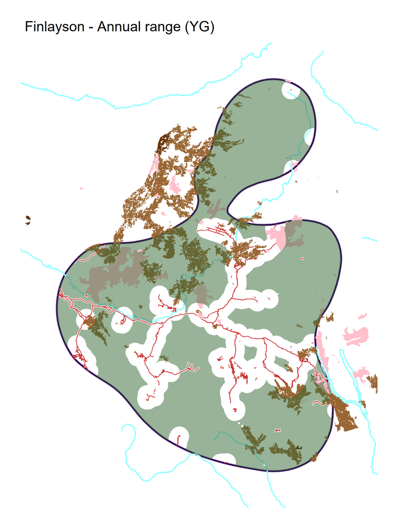

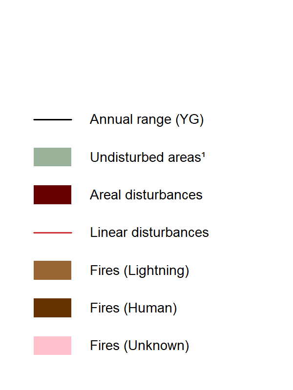

### Distance thresholds used per disturbance type to delineate undisturbed areas

This section describe the zone of influence assigned per disturbance industry/type.

#### Areal disturbances

| TYPE_FEATURE | TYPE_INDUSTRY | TYPE_DISTURBANCE | BUFFER_SIZE_M | AREA_KM2 |
| --- | --- | --- | --- | --- |
| Areal | Rural | Camp | 500 | 0.07645 |
| Areal | Mining | Quartz Mining - Minor | 500 | 0.93904 |
| Areal | Transportation | Airstrip | 500 | 0.36848 |
| Areal | Mining | Building | 500 | 0.00537 |
| Areal | Mining | Mining | 500 | 0.25037 |
| Areal | Mining | Drill Pad | 500 | 0.13025 |
| Areal | Transportation | Clearing | 500 | 0.47982 |
| Areal | Unknown | Unknown | 500 | 0.02786 |
| Areal | Unknown | Clearing | 500 | 0.21963 |
| Areal | Mining | Camp | 500 | 0.10786 |
| Areal | Mining | Gravel Pit / Quarry | 500 | 0.03920 |
| Areal | Mining | Laydown area | 500 | 0.03912 |
| Areal | Mining | Quartz Mining - Significant | 500 | 1.48557 |
| Areal | Transportation | Road Cut and Fill | 500 | 0.14692 |
| Areal | Transportation | Pullout / Turn Area | 500 | 0.07779 |
| Areal | Transportation | Gravel Pit / Quarry | 500 | 0.51171 |
| Areal | Rural | Homestead | 500 | 0.02457 |
| Areal | Forestry | Forestry | 500 | 0.01244 |
| Areal | Transportation | Unknown | 500 | 0.13155 |
| Areal | Unknown | Gravel Pit / Quarry | 500 | 0.01696 |
| Areal | Urban | Rural Residential | 500 | 0.00177 |
| Areal | Mining | Laydown Area | 500 | 0.01730 |
| Areal | Road Cut and Fill | Unknown | 500 | 0.00674 |

#### Linear disturbances

| TYPE_FEATURE | TYPE_INDUSTRY | TYPE_DISTURBANCE | BUFFER_SIZE_M | LENGTH_KM |
| --- | --- | --- | --- | --- |
| Linear | Transportation | Access Assumed | 5000 | 87.66 |
| Linear | Mining | Survey / Cutline - Quartz | 5000 | 141.25 |
| Linear | Transportation | Access Road | 5000 | 586.71 |
| Linear | Transportation | Trail | 500 | 124.90 |
| Linear | Mining | Survey / Cutline | 500 | 5.39 |
| Linear | Mining | Unknown | 500 | 0.90 |
| Linear | Transportation | Unpaved Road | 500 | 72.75 |
| Linear | Unknown | Right of Way | 500 | 16.53 |
| Linear | Mining | Trench | 500 | 11.16 |
| Linear | Unknown | Unknown | 500 | 1.36 |
| Linear | Transportation | Local Road | 500 | 50.99 |
| Linear | Utility | Unknown | 500 | 1.83 |
| Linear | Unknown | Survey / Cutline | 500 | 23.87 |
| Linear | Rural | Driveway | 500 | 2.64 |
| Linear | Transportation | Arterial Road | 500 | 220.83 |
| Linear | Utility | Electric Utility Corridor | 500 | 1.53 |

#### Other areal disturbances

```
## No other areal disturbances were included in the analysis
```

#### Other linear disturbances

```
## No other linear disturbances were included in the analysis
```

### Saved statistics and associated parameters

No statistics were saved to the summary statistics table prior to generate the report.

### About this report

This report was generated using the Caribou Cumulative Effects Explorer application developed through the BEACONs Project.

If you encounter any issues, have questions regarding the interpretation of the results, or would like additional information, please contact the project team at beacons@ualberta.ca.

When using results or figures derived from this report in presentations, publications, or other materials, please acknowledge the application as follows:

“Generated using the Caribou Cumulative Effects Explorer developed through the BEACONs Project.”

The application can be accessed here: https://beaconsproject.shinyapps.io/Caribou_CE_Disturbance_Explorer/